# Aprendizaje automático para el procesamiento de señales e imágenes médicas

Ingeniería Biomédica

Ph.D. Pablo Eduardo Caicedo Rodríguez

2026-09-18

# Aprendizaje automático para el procesamiento de señales e imágenes médicas

## Introduction

**Suposse…**

A dataset of M tuples $(\mathbf{x}_i, \mathbf{y}_i)$ with i = 1, …, M.

- $\mathbf{x}_i$: Inputs
- $\mathbf{y}_i$: Outputs

**What it is a neural network**

Is a mathematical function (sometimes called a network function) that takes some kind of input (typically multi-dimensional) called x iand generate some output.

## Introduction

**Network function**

- The output generated by the network function is called $\hat{y}_i$
- The network function normally depends on a certain number N of parameters, which we will indicate with $\mathbf{\theta}_k$
  $$\mathbf{\hat{y}}_i = f \left( \mathbf{\theta}_k, \mathbf{x}_i \right), where, k=0,1,2,\ldots,N$$

## Introduction

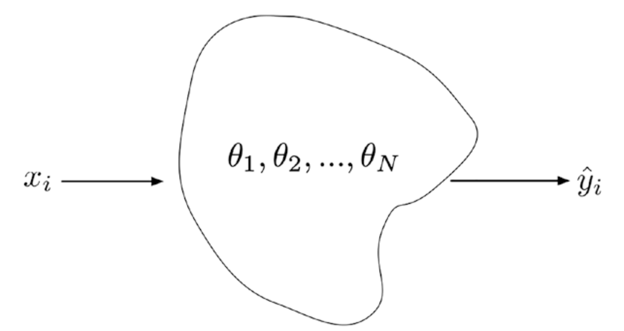

## Introduction

**Importante**

A neural network is nothing more than a mathematical function that depends on a set of parameters that are tuned, hopefully in some smart way, to make the network output as close as possible to some expected output.

- $\mathbf{x}_i \in \mathbb{R}^n$
- $\mathbf{y}_i \in \mathbb{R}^k$
- $i = 0,1,2,\ldots,M$
- $\mathbf{\theta}_k \in \mathbb{R}^N$
- $k = 0,1,2,\ldots,N$
- Loss function $L \left( \mathbf{\hat{y}}_i, \mathbf{y}_i \right) = L \left( f \left( \mathbf{\theta}_k, \mathbf{x}_i \right), \mathbf{y}_i \right)$
- Loss function measures how close are $\mathbf{\hat{y}}_i$ and $\mathbf{y}_i$

## Introduction

**Learning**

## A single neuron

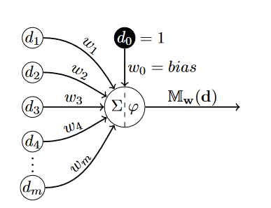

## Neural Network

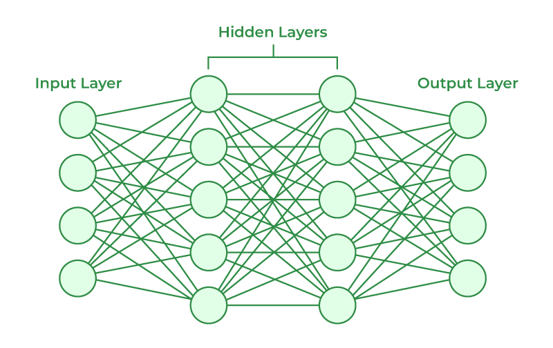

## Neural Network

[figure not shown]

Taken from [GeeksforGeeks](https://www.geeksforgeeks.org/underfitting-and-overfitting-in-machine-learning/)

## Regularization

Neural Networks have a great number of internal parameters for learning; which varying in a vast range of values.

This number of parameters is fundamental for neural network knowledge representation

**Problem**

But if this number increases too much the neural network is prone to overfitting

## Regularization

**Definition**

Regularization techniques reduce the possibility of a neural network overfitting by constraining the range of values that the weight values within the network hold.

$$\begin{eqnarray}
L(\mathbf{x},\mathbf{y}) = \sum_{k=1}^N \left( y_k - f \left( x_k \right) \right)^2 \\
f \left( x \right) = \theta_0+\theta_1 x + \theta_2 x^2 + \theta_3 x^3 + \theta_4 x^4 \\
f \left( x \right) = \theta_0+\theta_1 x + \theta_2 x^2
\end{eqnarray}$$

## Regularization

- Regularization works on assumption that smaller weights generate simpler model and thus helps avoid overfitting.
- The simpler model is less prone to overfitting.
- Adding the regularization term to the sum of squared differences between the actual value and predicted value.

## Regularization

$$\begin{eqnarray}
L(\mathbf{x},\mathbf{y}) = \sum_{k=1}^N \left( y_k - f \left( x_k \right) \right)^2 + \lambda \sum_{k=1}^N \theta_k
\end{eqnarray}$$

**Nota**

$\lambda$ is the penalty term or regularization parameter which determines how much to penalizes the weights.

## Types of Regularization

**L1 Regularization or Lasso or L1 norm**

- L1 penalizes sum of absolute value of weights.
- L1 has a sparse solution.
- L1 has multiple solutions.
- L1 has built in feature selection.
- L1 is robust to outliers.
- L1 generates model that are simple and interpretable but cannot learn complex patterns.

$$\begin{eqnarray}
L(\mathbf{x},\mathbf{y}) = \sum_{k=1}^N \left( y_k - f \left( x_k \right) \right)^2 + \lambda \sum_{k=1}^N \lvert \theta_k \rvert
\end{eqnarray}$$

**L2 Regularization or Ridge Regularization**

- L2 regularization penalizes sum of square weights.
- L2 has a non sparse solution
- L2 has one solution
- L2 has no feature selection
- L2 is not robust to outliers
- L2 gives better prediction when output variable is a function of all input features
- L2 regularization is able to learn complex data patterns

$$\begin{eqnarray}
L(\mathbf{x},\mathbf{y}) = \sum_{k=1}^N \left( y_k - f \left( x_k \right) \right)^2 + \lambda \sum_{k=1}^N \theta_k^2
\end{eqnarray}$$

## Evaluation

**Regression**

- $R^2$
- Residual graph
- Autocorrelation analysis

**Classification**

- Confusion Matrix(Matriz de Confusión)
- Precision(Precisión)
- Recall(Exhaustividad)
- F1-score(Valor-F)
- Accuracy(Exactitud)
- True Positive(Positivos Verdaderos)
- True Negative(Negativos Verdaderos)
- False Positive(Positivos Falsos)
- False Negative(Negativos Falsos)

## Evaluation of a classification model

**Confusion Matrix**

“Also known as an error matrix, is a specific table layout that allows visualization of the performance of an algorithm, typically a supervised learning one.”

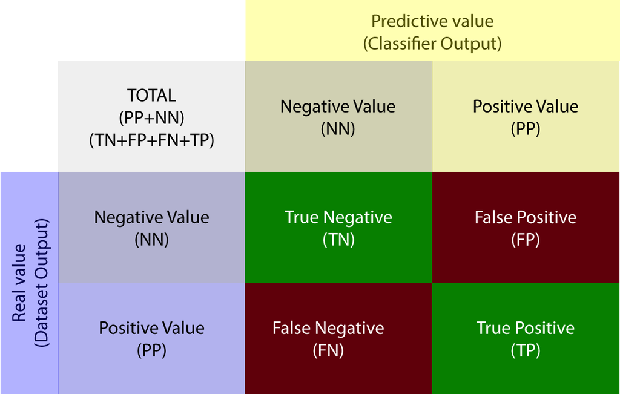

## Evaluation of a classification model

**True Negative**

Values that being negative have been classified as negative

**True Positive**

Values that being positive have been classified as positive

**False Positive**

Values that being negative have been classified as positive

## Evaluation of a classification model

**Sensitivity or Recall**

How good is my classifier at detecting positive cases?
$$\frac{TP}{TP+FN}$$

**Specificity**

**Precision**

How credible is my classifier when it detects a positive case?
$$\frac{TP}{TP+FP}$$

**Accuracy and Balance Accuracy**

How many cases the classifier correctly identifies?
$$Accuracy = \frac{TP+TN}{TP+FP+FN+TN}$$
$$BalancedAccuracy = \frac{Specificity+Sensitivity}{2}$$

## Evaluation of a classification model

**Prevalence**

How often does the positive condition actually occur in our sample?
$$\frac{TP+FN}{TP+FP+FN+TN}$$

**Detection Rate**

Percentage of true positives
$$\frac{TP}{TP+FP+FN+TN}$$

**Detection Prevalence**

Percentage of positives
$$\frac{TP+FP}{TP+FP+FN+TN}$$

**Harmonic mean of recall and precision.**

$$2\frac{\left( Precision \right) \left( Sensitivity \right)}{Precision+Sensitivity}$$

## Multiclass Confusion Matrix

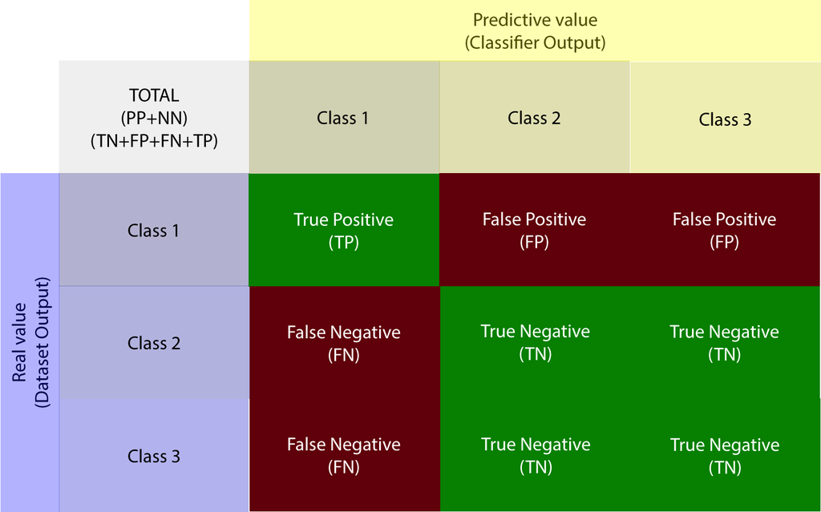

For Class 1

## Multiclass Confusion Matrix

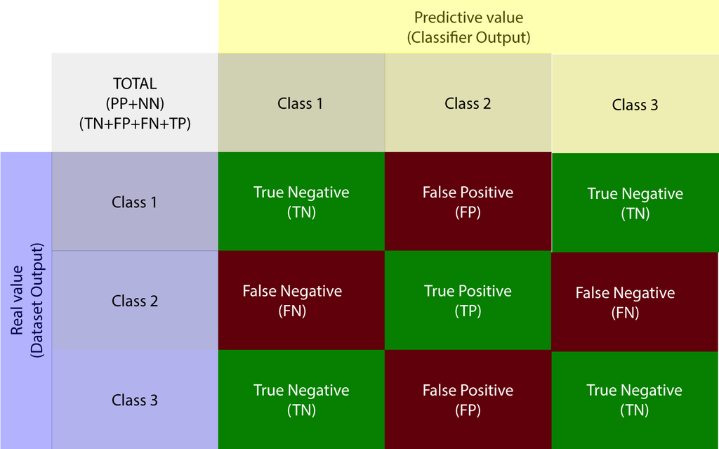

For Class 2

## Multiclass Confusion Matrix

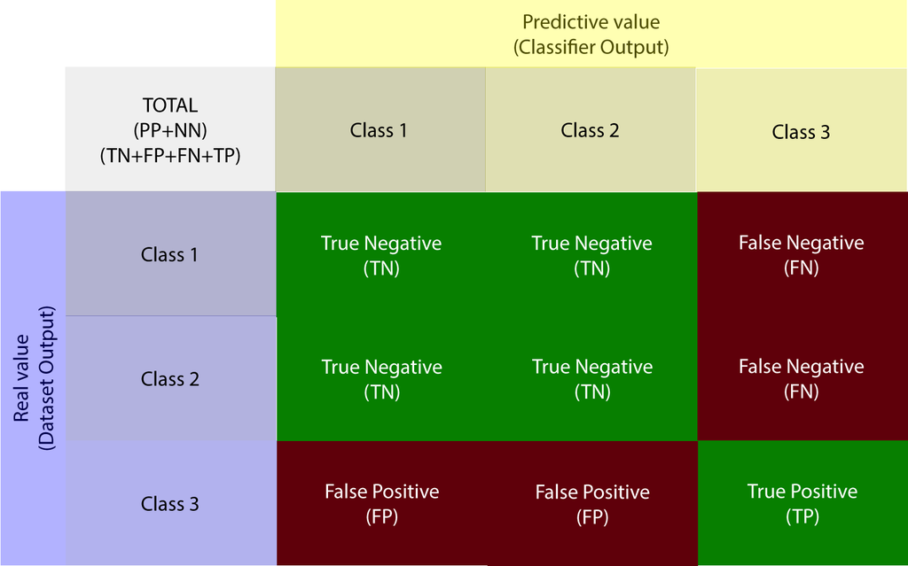

For Class 3